# act_report

## WeRateDogs Analysis Results

### WeRateDogs is a Twitter account that rates people's dogs with a humorous comment about the dog. The account was started in 2015 by college student Matt Nelson, and has received international media attention for its popularity. I conducted an analysis using Jupyter Notebook thanks to Udacity, and these are some of the conclussions I was able to deduct from the analysis.

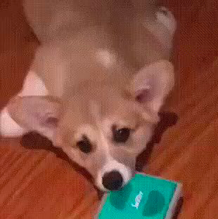

### 2. I wanted to know what time of day had the most retweets and favorite counts. Dogs posted around 6:00 a.m. were most likely to recieve high retweets and favorites compared to dogs posted on any other time of the day.

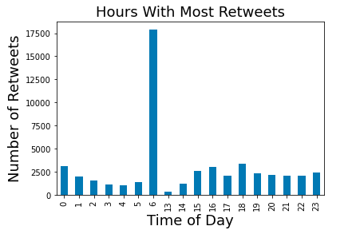

### 3. According to the posts made on WeRateDogs, the five most common types of dogs includes Golden Retriever, Labrador Retriever, Pembroke, Chihuahua, and Pug. The Golden Retriever is the most common type of dog.

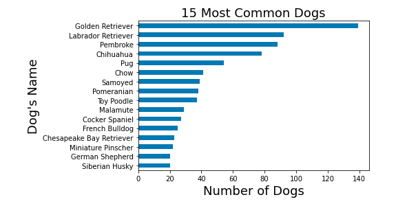

#### It looks great though. This is an image of a Golden Retriever

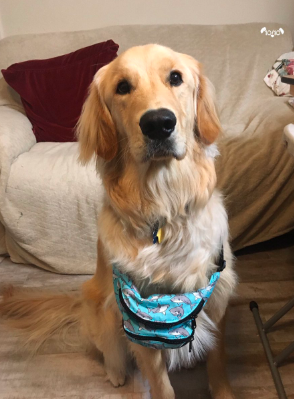

### 4. I also wanted to know if there was any relationship between dog's ratings and retweets. There is a positive correlation between a dog's rating and the number of retweets a dog get. I.e., the higher the rating of a dog, the higher the number of retweets that particular dog is likely to receive.

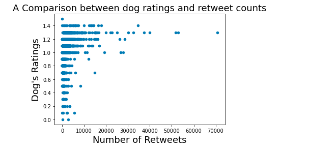

### There was also a positive correlation between dog's rating and retweets. So if a dog was rated higher on WeRateDogs, there was a high probability of getting a higher number of favorites.

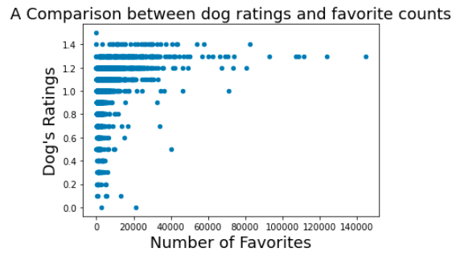

## Limitations

1. There might have quality issues in the data that may not have been detected and/or corrected.
2. More types of analyses may be done be done on the data to get more insights